# Gene Expression Fundamentals using DESeq

Devika Godbole

11/19/2020

*In this project, we are primarily interested in understanding how the differences in gene expression between the light and dark conditions vary by genotype. To this end, we will use DESeq to look for genes with significant interaction terms between genotype and timepoint.*

*To begin, we construct a DESeqDataSet object using time + genotype + time:genotype as the design argument and perform a hypothesis test specifically for the significance of the interaction term time:genotype in the model.*

```
## [1] 1429
```

```
## [1] 142.9
```

If we wanted to keep the false discovery rate (FDR) to 0.10 (or 10%), we would conclude that there was evidence of a significant time:genotype interaction term for 1429 genes from the full data set.

The expected number of false positive discoveries out of the list of genes with evidence of significant interaction terms determined this way would be 142.9 because 1429 samples that were below the cutoff adjusted p value and we expect 10% of those to be false discoveries.

*Next, the data was normalized with DESeq and log-transformed with an offset and the dimensions of lgNorm are outputted.*

```
## [1] 18399    15
```

*Next, we generate a principal components analysis (PCA) plot for the data in lgNorm. PC1 scores are outputted.*

```
##                  PC1
## 14BENDDAY2 -68.74950
## 14BENDDAY4 -89.92308
## 14BEXDARK2  70.33168
## 14BEXDARK3  42.61680
## 14BEXDARK4  51.28013
## 4GENDDAY2  -56.82026
```

```
##                    PC1
## AT1G01010 0.0013091281
## AT1G01020 0.0038969106
## AT1G01030 0.0023435409
## AT1G01040 0.0029185779
## AT1G01050 0.0005720931
## AT1G01060 0.0565535022
```

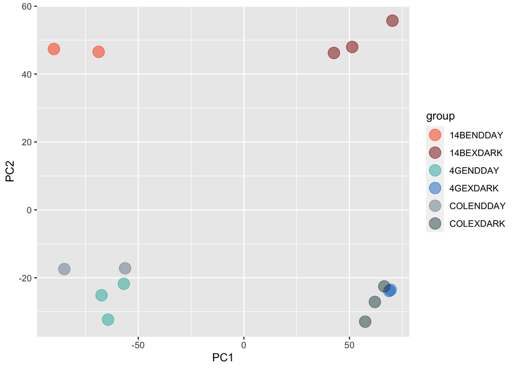

From the PCA plot, it appears that the the DAY samples versus the DARK samples are the most separated from each other along the PC1 direction. Along the PC2 direction, the 14B (mutant lacking two genes) samples are separated from both the the 4G (mutant lacking the one gene) and COL (wild type) samples.

*Next, we extract a vector containing the ids of the genes associated with the assigned gene set, GO:0009631 and store it as a txt file named “mygenes”.*

*Next, we generate a principal components analysis (PCA) plot for the data in lgGo.PC1 scores are outputted for the genes in my geneset.*

```
##                  PC1
## 14BENDDAY2 -2.276832
## 14BENDDAY4 -5.244588
## 14BEXDARK2  7.079687
## 14BEXDARK3 -1.760498
## 14BEXDARK4  5.854325
## 4GENDDAY2  -4.715802
```

```
##                   PC1
## AT1G10760 -0.20489541
## AT1G11760  0.04439034
## AT1G19120  0.02053986
## AT1G20440  0.01067852
## AT1G20450 -0.01814600
## AT1G28520  0.10807497
```

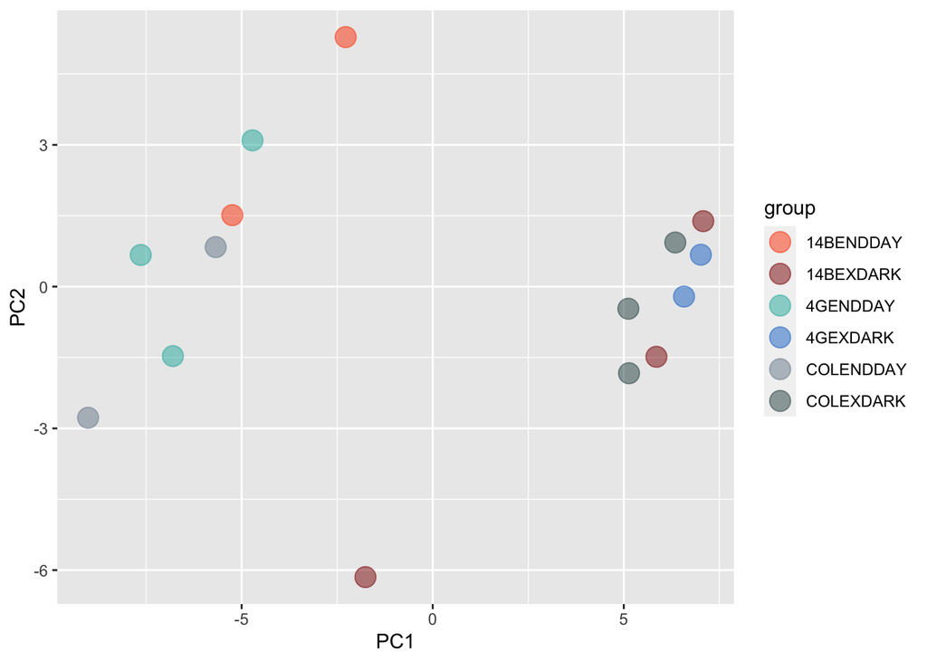

From the PCA plot, it still appears that the the DAY samples versus the DARK samples are the most separated from each other along the PC1 direction. Along the PC2 direction, there is not a very clear separation between any of the genotypes. The 14B DARK and 14B DAY groups have much more variation/less clustering in this sample compared to the full data set. The 14B group as a whole does not fit any pattern when compared to the 4G group and the Col group.

*Next, we generate a clustered heatmap of the differences in each gene’s (log-transformed normalized) expression level from it’s (the gene’s, that is) mean.*

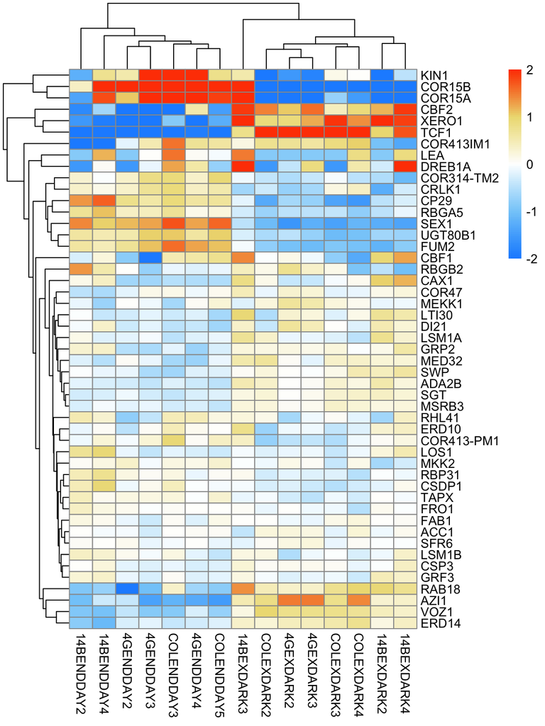

From the sample-axis dendrogram, we can see thee are two major groups- one with the samples from DAY and another with samples from DARK. The gene expression patterns between these two groups are inversely related upon visual inspection of the heatmap. From the gene-axis dendrogram, we can see that there is a division between the gene group {KIN1, COR15B, COR15A} and the rest of the genes in the gene ontology. The gene group of interest have much higher differences in expression values from the means of each gene. The gene CFB2, XERO1, TCF1, DRES1A, and AZI1, not a part of our gene group of interest, also appear to have strong deviation from the mean gene expression levels.

*Finally, we create a stripchart showing the expression levels of these genes by time and genotype (using the function provided).*

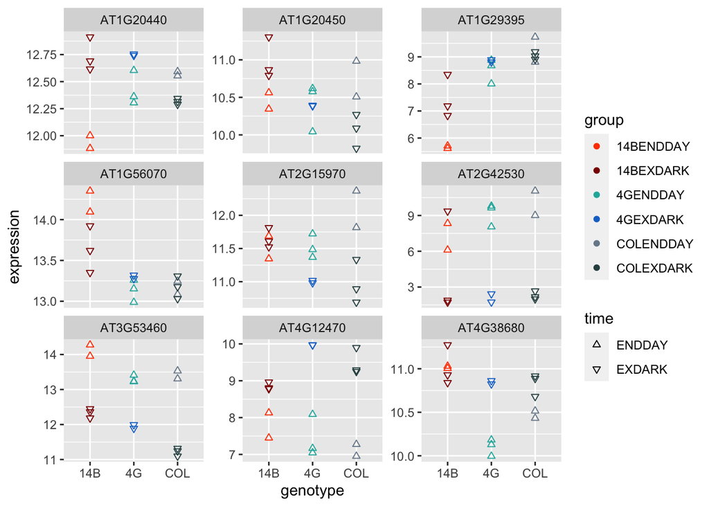